# L2 slides

### Quick Recap

We talked about **Large Language Models** last week.

They handle natural language, but are much more capable of doing generalized tasks than NLP models.

The **longer the input+ouput**, the **larger** the demand on the memory of the device, i.e. the **longer** it takes to generate response.

Most SOTA LLMs are not democratized (personalizable), OpenAI still has the best model, but this is quickly changing.

**This course's hackathon encourages you to leverage LLM to tackle early detection of humanitarian crisis!**

Once again just a useful tip: try to leverage the two graphical software programming solutions to do fast-prototyping of your solution!

## Perspectives on Sustainability

October 7th, 2023

### Top-Down Sustainability

### Conceptual Perspective on Sustainability

- **Holistic Approach**: Undestand that everything is interconnected
- **Triple Bottom Line**: Social, Environmental and Financial Aspects
- **Precautionary Principle**: Responsibility of proof lies on advocates of potentially harmful actions.
- **Regenerative Design**: Aim to restore or regenerate resources and the environment

### Triple bottom line (TBL, or 3BL)

*Accounting framework* with three parts: social, environmental and economic, 1994.

- **People, Planet, Profit**
- "bottom line" refers to either the "profit" or "loss", or
  - full cost accounting: bring a broader definition of bottom line into public consciousness
  - stakeholders rather than shareholders: anyone who is influenced directly/indirectly by actions of the firm

```python
TBL
```

[figure not shown]

```python
Thinking_n_Systems
```

[figure not shown]

**Thinking in Systems: a Primer, 2008**

- Donella H. Meadows
- "A system is an interconnected set of elements that is coherently organized in a way that achieves something"
- Dynamics and interconnected

### Technical Perspective on Sustainability

Some red-hot areas that we could cover next week, some long-standing fields, and some dwindling fields that has not seen much development despite public attention.

- **Renewable Energy**: Solar panels, wind turbines, hydroelectric dams
- **Green Building**: Energy-efficient design, green roofs, sustainable materials
- **Waste Management**: Recycling, composting, anaerobic digesters.
- **Water Management**: Efficient irrigation, wastewater treatment, greywater systems.
- **Sustainable Agriculture**: Organic farming, agroforesttry, precision agriculture
- **Transportation:** Electric vehicles, public transportation, bike-sharing

### Bottom-Up Sustainability

Concepts and angles that we could cover.

- Advanced Materials
- **Circular Economy**
- Smart Cities
- Conservation and Biodiversity
- Financial Models and Incentives
- Challenges and Considerations

### Circular Economy

1. Basics
- **Definition**: A circular economy is designed to rebuild capital: financial, manufactured, human, social or natural. This ensures enhanced flows of goods/services.
- **Objective**: Works effectively at every scale from large to small business and from orgs to individuals, globally to locally.
1. Core Principles
- Design Out Waste and Pollution: longevity, renewability, recyclability, minimizing/eliminating wastes pollution;
- Keep Products and Materials **in Use**: seeks to design products for durability, reuse, remanufacturing and eventually recycling;
- Regenerate Natural Systems: Seeks to regenerate and enhance natural resources;
1. Key Components:
- Product as a Service: Companies offer the use of a product as a service, ensuring its return and potential for reuse or recycling;
- Reverse Logistics: Creating mechanisms to take back used products from consumers, either to refurbish, remanufacture or recycle them;
- Eco-design: Desining products from its offset with the intention of a longer lifespan, ease of repair, and recyclability;
- Sharing Platforms: Platforms or business that promote sharing, thus reducing the need for individual ownership of goods and assets;
1. Benefits: Economic, Environmental and Societal

### What about Life Cycle Analysis?

LCA is a systematic method to assess the environmental impacts associated with allthe stages of a product's life.

Note the 4/5: 4 stages of LCA and 5 stages of "Life Cycle".

[figure not shown]

```python
Image('ecochainlca.png')#Retrieved from https://mail.ecochain.com/hubfs/Whitepapers/Ecochain_QuickGuidetoLCA.pdf
```

LCA is the tool that enables the calculation of the carbon emissions like the one below:

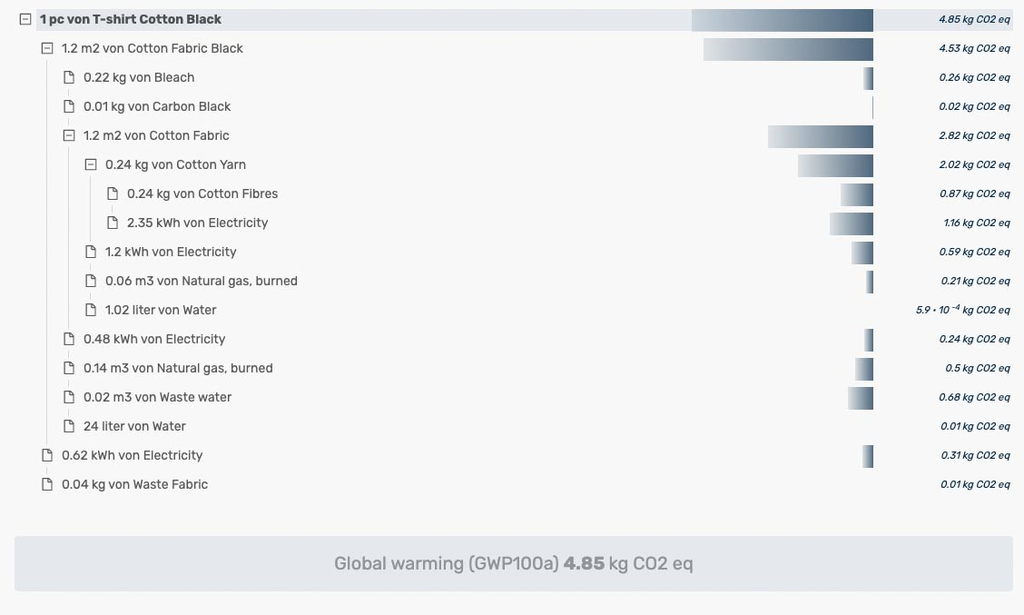

```python
Image('https://ecochain.com/wp-content/uploads/2023/05/mobius_phase3_1.jpg')
```

```python
#Also the traceability of carbon emission by source:
Image(url='https://ecochain.com/wp-content/uploads/2023/05/mobius_flatview.png')
```

[figure not shown]

### LCA vs. Circular Economy

**Tool vs. Concept**

| Feature/Aspect | Life Cycle Analysis (LCA) | Circular Economy |
| --- | --- | --- |
| **Main Focus** | Assessment of environmental impacts of a product/service. | Design systems to minimize waste & maximize resource use. |
| **Scope** | Entire life cycle of a product. | Entire economic systems and processes. |
| **Core Principles** | Source, Manufacture, Use, End-of-life | Design out waste, Keep products/materials in use, Regenerate natural systems. |
| **Quantitative vs. Qualitative** | Primarily quantitative (environmental impacts). | Both (environmental, social, economic aspects). |
| **Frameworks/Tools** | ISO 14040 and 14044 standards. | Cradle to Cradle, Blue Economy, Regenerative Design. |
| **Applications** | Product design, policy-making, marketing. | Business models, product design, urban planning, policy-making. |
| **Limitations** | May neglect economic or social sustainability aspects. | Systemic change can be challenging to implement. |

### **Emerging Trends & Dominating Concepts**:

1. **Circular Economy**:
   - As discussed, the shift from a linear "take, make, dispose" model to a circular model that emphasizes reuse, repair, and recycling.
2. **Regenerative Design**:
   - Beyond sustainability, this approach seeks to restore, renew, and revitalize its sources of energy and materials, creating systems that are not just sustainable but also positively regenerative.
3. **Climate Change & Carbon Neutrality**:
   - With the urgency of climate change, achieving carbon neutrality (balancing carbon emissions with carbon removal) is a top priority for many countries and organizations.
4. **Biodiversity & Ecosystem Services**:
   - Recognizing the value of biodiversity and the services ecosystems provide, from pollination to clean water, and integrating that into decision-making.
5. **Sustainable Development Goals (SDGs)**:
   - Adopted by all United Nations Member States in 2015, these 17 interconnected goals provide a blueprint for peace and prosperity for people and the planet.
6. **Social Equity & Environmental Justice**:
   - Addressing the inequalities in who carries the burdens of environmental degradation and ensuring that sustainability benefits everyone, regardless of race, class, or income.
7. **Green Finance & ESG Investing**:
   - A growing trend in the financial sector, focusing on investments that have positive environmental, social, and governance (ESG) outcomes.
8. **Digital Technology for Sustainability**:
   - Leveraging digital tools, from AI to blockchain, to enhance sustainable practices, monitor ecological health, and ensure transparency in supply chains.
9. **Nature-based Solutions**:
   - Interventions that harness the power of nature to address societal challenges, from carbon sequestration through reforestation to urban green spaces for community well-being.

### AT&T NOC, A VERY old Case Study

**Examining Technological Disasters.**

1. AT&T handles more than 70% of the long-distance traffic of the United States
2. Company proud of the robustness of its NOC (video in 1989)
3. This is soon to change in 1990.

```python
NOC
```

[video not shown]

1. Jan 15, 1990, a single switch at one of AT&T's 144 switching centers suffered a minor mechanical malfunction
2. Programmed reinitialization took 4-5 seconds, but the signal got jammed in the comms channel;
3. Surrounding switches got 'infected';
4. The fault switches' coming back-online congested the whole network;
5. This repeated **iteratively** and resulted in waves of self-induced shut-downs;
6. 50 million calls blocked and 9 hours to stablize the system. All from one line of faulty code.

### What's wrong with this code?

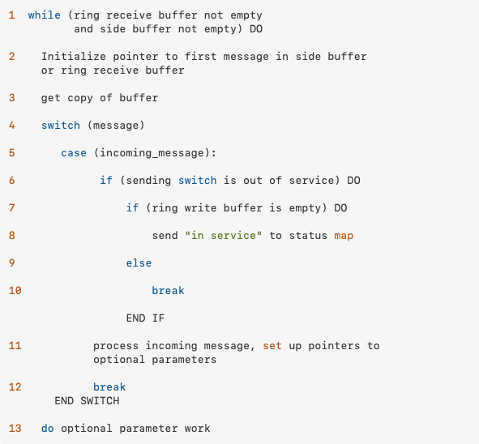

```python
Image('switch.png')
```

### What does the AT&T new Disaster Recovery Warehouse look like?

```python
%%HTML
<iframe width="1120" height="630" src="https://www.youtube.com/embed/QgFuNDRQWQg?si=vSmq3SWiR2jUTWrz&amp;start=2" title="YouTube video player" frameborder="0" allow="accelerometer; autoplay; clipboard-write; encrypted-media; gyroscope; picture-in-picture; web-share" allowfullscreen></iframe>
```

[video not shown]

### Some other notable technological failures

1. Airbus A380 (2006): Software version incompatible btw German and French CATIA
2. Millennium Bug (2000): Y2K two-digit year -> 2000 problem, cost: approx. 400Billion GBP
3. Explosion of Ariane 5 (1996): Unmanned satellite-launching rocket blew up seconds after take-off: stuffing 64-bit number into 16-bit space.

Quiz: We talked about something similar to this last lecture, what was the concept? Hint: Relates to how LLMs run.

### Digital Trends - AI & Blockchain

Absolutely! Digital technology, including AI and blockchain, holds significant promise in driving sustainability initiatives across various sectors. Let's delve into each:

#### **1. Artificial Intelligence (AI)**:

AI offers a range of applications for sustainability, such as:

- **Data Analysis**: AI can analyze vast amounts of environmental data to track changes, predict future scenarios, and inform sustainability strategies. For example, AI can predict deforestation rates or assess the health of coral reefs through satellite images.
- **Energy Efficiency**: AI-driven algorithms can optimize energy use in buildings, data centers, and transportation systems. For instance, Google used AI to reduce the energy used for cooling its data centers by 40%.
- **Natural Resource Management**: AI can be used to optimize irrigation in agriculture, reducing water use, or to predict and prevent overfishing in marine ecosystems.
- **Waste Management**: AI can sort and separate waste more efficiently, improving recycling rates and reducing landfill waste.
- **Climate Modeling**: AI can improve the accuracy of climate models, making them faster and more precise, helping policymakers make informed decisions.

Leverage AI for data analysis to draw insights on better management/operations.

#### **2. Blockchain**:

Blockchain, the technology behind cryptocurrencies, offers transparency and traceability, crucial for several sustainability applications:

- **Supply Chain Transparency**: Blockchain can track products from origin to consumer. This ensures that products are sustainably sourced and that the supply chain is free from practices like child labor or environmental degradation.
- **Decentralized Energy Grids**: Blockchain can enable peer-to-peer energy trading, allowing people to sell excess energy (like solar power) directly to neighbors, promoting decentralized and renewable energy sources.
- **Carbon Credits & Offsetting**: Blockchain can track carbon credits, ensuring that they are not double-counted and that companies are accurately offsetting their emissions.
- **Sustainable Finance**: Blockchain can ensure that green bonds or other sustainable financial instruments are genuinely used for green initiatives by offering transparency into how funds are used.
- **Water Quality & Land Use**: Communities can use blockchain to maintain transparent records of water quality or to verify sustainable land use practices.

Leverage blockchain allows better transparency and traceability than existing technologies.

Summing them up succinctly, the benefit of blockchain over existing technologies are:

1. **Distributed Ledger**: Data is stored across a decentralized network, ensuring no single point of failure or control. This enhances security and reduces the risk of data tampering.
2. **Fully Automated Process**: With tools like smart contracts, processes are automated, ensuring they are executed exactly as intended without human interference.
3. **Visibility of Shared Records**: Every participant can see the transactions, ensuring transparency and trust among all involved.
4. **Immutability**: Once a transaction is confirmed on the blockchain, it cannot be reversed or altered. This ensures a permanent, tamper-proof record.

Risks introduced by blockchain/crypto:

1. **Irreversibility of Transactions**: As you pointed out, once a transaction is confirmed, it can't be reversed. This means errors or unintended transactions can't easily be corrected.
2. **Scalability Issues**: Traditional blockchains like Bitcoin and Ethereum can handle a limited number of transactions per second, leading to potential bottlenecks as usage grows.
3. **Energy Consumption**: Proof-of-work, a common consensus mechanism in blockchains, is energy-intensive. For example, Bitcoin mining consumes more energy than some entire countries.
4. **Privacy Concerns**: While transactions are encrypted, the public nature of blockchain means data is visible to everyone. This can pose privacy concerns, especially in sensitive applications.
5. **Regulatory and Legal Challenges**: Since blockchain is a relatively new technology, regulatory frameworks in many countries are still evolving. This can lead to potential legal uncertainties.
6. **Potential for 51% Attacks**: In blockchains where more than 50% of the network's mining hash rate is controlled by a single entity, there's a risk that they could double-spend coins, preventing new transactions from gaining confirmations.
7. **Lack of Standardization**: There are many different blockchains with different technologies and standards. This can complicate integration and widespread adoption.
8. **Complexity**: For many, blockchain remains a complex and hard-to-understand technology, which can slow its adoption.
9. **Storage Concerns**: As more transactions are added, the size of the blockchain grows, leading to potential storage concerns.
10. **Smart Contract Vulnerabilities**: If not coded correctly, smart contracts can contain vulnerabilities that malicious actors might exploit.

### Blockchain ≠ Cryptocurrency

But we obviously want to address it a little bit at this course.

Blockchain: Peer-to-Peer Architecture, a decentralized, distributed system where participants/nodes connect directly with each other rather than through a central server;

```
- P2P networks also includes other technology as well such as BitTorrent;
- Think of it as P2P principles combined with cryptography and consensus algorithms;
- Many users access blockchains through centralized platforms/exchanges (Coinbase, but also FTX, JPEX)
```

At such, cascading failures like AT&T may not be fully avoidable.

##### **1. Protocol Vulnerabilities**:

- If there's a flaw in the core protocol of a blockchain, it could indeed be exploited to affect the entire network. This has happened in the past with certain cryptocurrencies and required urgent fixes.

##### **2. Broadcast Mechanism**:

- In a blockchain network, when a transaction or a block is broadcasted, it's propagated through the network. If this transaction contains malicious code or an exploit (and if the blockchain were somehow designed to execute such code), it could affect nodes that process that transaction.

##### **3. Smart Contract Vulnerabilities (specifically for platforms like Ethereum)**:

- Ethereum and similar platforms allow for "smart contracts," which are self-executing contracts with the terms directly written into code. If there's a vulnerability in a smart contract, it can be exploited. The most infamous case of this was the DAO (Decentralized Autonomous Organization) hack in 2016, where a vulnerability was exploited to siphon off a significant amount of Ether.

##### **4. Resilience of Decentralization**:

- One of blockchain's strengths is its decentralized nature. To disrupt the entire network, an attacker would need to compromise a significant portion of nodes, which is challenging (but not impossible) due to the distributed nature of the network.

##### **5. Forks as a Solution**:

- In situations where a significant vulnerability is found or exploited, one solution the community might opt for is a fork, effectively creating a new path in the blockchain from a point before the exploit. This was the case after the DAO incident, leading to Ethereum (ETH) and Ethereum Classic (ETC).

##### **6. Constant Evolution and Upgrades**:

- The blockchain and cryptocurrency community is very active. Potential vulnerabilities are continuously being researched, and updates and patches are regularly proposed and implemented to address known issues.

### Crypto Miners are horrible news for sustainability: 1 miner = 1 single household

### Final Take-Aways

1. Sustainability comes in all shapes and flavors beyond implementing technology
2. LCA vs. Circular Economy
3. Landing sustianbility requires adequate policy support
4. Sustainable thinking empowers systems to be future-proof - flip side of this is technology disaster.
5. How AI/blockchain serves the purpose of sustainability better - or worse.

### Advanced Materials

▶ Materials science: Discovery and implementation of stronger, lighter, durable substances.

▶ Graphene: Potential applications from water filtration to efficient batteries.

▶ Bioplastics: Sustainable alternative to traditional plastics from renewable biomass sources.

### Smart Cities

▶ Integration of digital technology for enhanced urban services.

▶ **Smart Grids**: Systems that respond to energy demand.

▶ **Urban Agriculture**: AI and IoT driven vertical farming.

▶ **Traffic Management**: Sensors and AI for reduced congestion.

### Conservation and Biodiversity

▶ Remote Sensing: Monitoring ecosystems with drones and satellites.

▶ Genome Sequencing: Understand species genetically.

▶ VR and AR: Tools for impactful environmental education.

### Financial Models and Incentives

▶ **Carbon Trading Platforms**: e.g. Blockchain tracks carbon credits footprints, AI used to identify patterns of false promises in carbon reduction reports.

### Challenges and Considerations

▶ **E-waste**: Increased electronic waste poses hazards.

▶ **Energy Consumption**: High energy consumption of digital solutions e.g. miners for crypto-currencies: 1-1 relationship to a single family household energy consumption.

▶ **Ethical Concerns**: Considerations on genetic modifications and potential ecosystem impact.